# Day 1, Session 3: Data Visualization in R

Dusica Filipovic Durdevic

2026-09-14

## First we make sure our working directory is set to what we want – ideally, where our data is located

```r
setwd("C:/Eowyn/Dokumenti/Obuke/!MOJE_2026")
```

- If you don’t believe it, you can check:

```r
getwd()
```

```
## [1] "C:/Eowyn/Dokumenti/Obuke/!MOJE_2026"
```

## Next, we load a small and clean data frame

- If we haven’t set the working directory, the path needs to be adjusted to match your own hard drive:

```r
df <- read.table("Day1_Session3_data.txt",sep="\t", header=TRUE)
```

- Let’s check the dimensions (number of rows and columns) of the data frame

```r
dim(df)
```

```
## [1] 100   6
```

- We see there are 100 rows and 6 columns (we can also see this in the Environment pane)
- Let’s inspect the column names

```r
colnames(df)
```

```
## [1] "Participant"       "Manipulation"      "DominantHand"
## [4] "ReadingExperience" "IQ"                "RT"
```

## Let’s take a quick look at the first few rows

```r
head(df)
```

```
##   Participant  Manipulation DominantHand ReadingExperience IQ   RT
## 1          s1 control_group   lefthanded               370 92 1648
## 2          s2 control_group   lefthanded                80 94 1370
## 3          s3 control_group   lefthanded               390 96 1663
## 4          s4 control_group   lefthanded                90 96 1396
## 5          s5 control_group   lefthanded               220 97 1521
## 6          s6 control_group   lefthanded               110 97 1409
```

- We can see that the first column contains participant codes, the second contains group membership within the Manipulation variable, the third contains the same for the DominantHand variable, the fourth for ReadingExperience, the fifth for IQ, and the sixth for RT

## We can check the data type in each column

```r
class(df$Participant)
```

```
## [1] "character"
```

```r
class(df$Manipulation)
```

```
## [1] "character"
```

```r
class(df$DominantHand)
```

```
## [1] "character"
```

```r
class(df$ReadingExperience)
```

```
## [1] "integer"
```

```r
class(df$IQ)
```

```
## [1] "integer"
```

```r
class(df$RT)
```

```
## [1] "integer"
```

## Let’s see which levels exist for our categorical variables

```r
levels(df$Manipulation)
```

> Caution

> Remember the character vs factor distintion!
- Let’s change the type of categorical variables

```r
df$Participant <- as.factor(df$Participant)
```

```r
levels(df$Participant)
```

```
##   [1] "s1"   "s10"  "s100" "s11"  "s12"  "s13"  "s14"  "s15"  "s16"  "s17"
##  [11] "s18"  "s19"  "s2"   "s20"  "s21"  "s22"  "s23"  "s24"  "s25"  "s26"
##  [21] "s27"  "s28"  "s29"  "s3"   "s30"  "s31"  "s32"  "s33"  "s34"  "s35"
##  [31] "s36"  "s37"  "s38"  "s39"  "s4"   "s40"  "s41"  "s42"  "s43"  "s44"
##  [41] "s45"  "s46"  "s47"  "s48"  "s49"  "s5"   "s50"  "s51"  "s52"  "s53"
##  [51] "s54"  "s55"  "s56"  "s57"  "s58"  "s59"  "s6"   "s60"  "s61"  "s62"
##  [61] "s63"  "s64"  "s65"  "s66"  "s67"  "s68"  "s69"  "s7"   "s70"  "s71"
##  [71] "s72"  "s73"  "s74"  "s75"  "s76"  "s77"  "s78"  "s79"  "s8"   "s80"
##  [81] "s81"  "s82"  "s83"  "s84"  "s85"  "s86"  "s87"  "s88"  "s89"  "s9"
##  [91] "s90"  "s91"  "s92"  "s93"  "s94"  "s95"  "s96"  "s97"  "s98"  "s99"
```

```r
df$Manipulation <- as.factor(df$Manipulation)
levels(df$Manipulation)
```

```
## [1] "control_group"      "experimental_group"
```

```r
df$DominantHand <- as.factor(df$DominantHand)
levels(df$DominantHand)
```

```
## [1] "lefthanded"  "righthanded"
```

## We can also inspect the type of variables all at once:

```r
str(df)
```

```
## 'data.frame':    100 obs. of  6 variables:
##  $ Participant      : Factor w/ 100 levels "s1","s10","s100",..: 1 13 24 35 46 57 68 79 90 2 ...
##  $ Manipulation     : Factor w/ 2 levels "control_group",..: 1 1 1 1 1 1 1 1 1 1 ...
##  $ DominantHand     : Factor w/ 2 levels "lefthanded","righthanded": 1 1 1 1 1 1 1 1 1 1 ...
##  $ ReadingExperience: int  370 80 390 90 220 110 260 430 320 340 ...
##  $ IQ               : int  92 94 96 96 97 97 97 99 100 100 ...
##  $ RT               : int  1648 1370 1663 1396 1521 1409 1540 1706 1609 1627 ...
```

## We can also visually inspect the variables in the data frame (and their relationship):

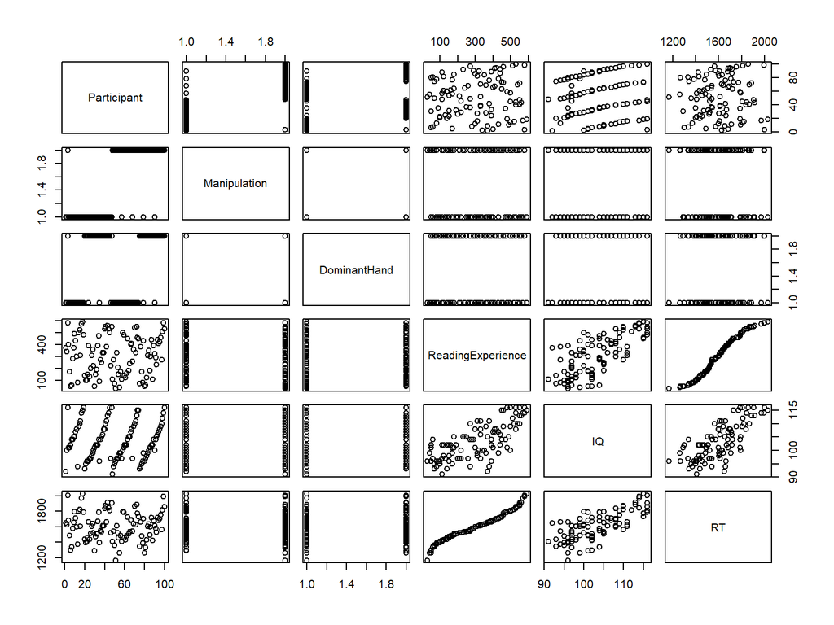

```r
plot(df)
```

## Let’s visualize a single variable

- start by building a frequency table using table(), then display that table

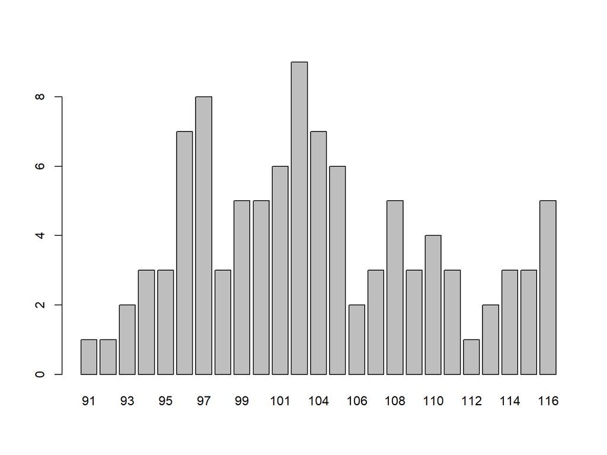

```r
barplot(table(df$IQ))
```

## Let’s add axis labels, a title, and change the color

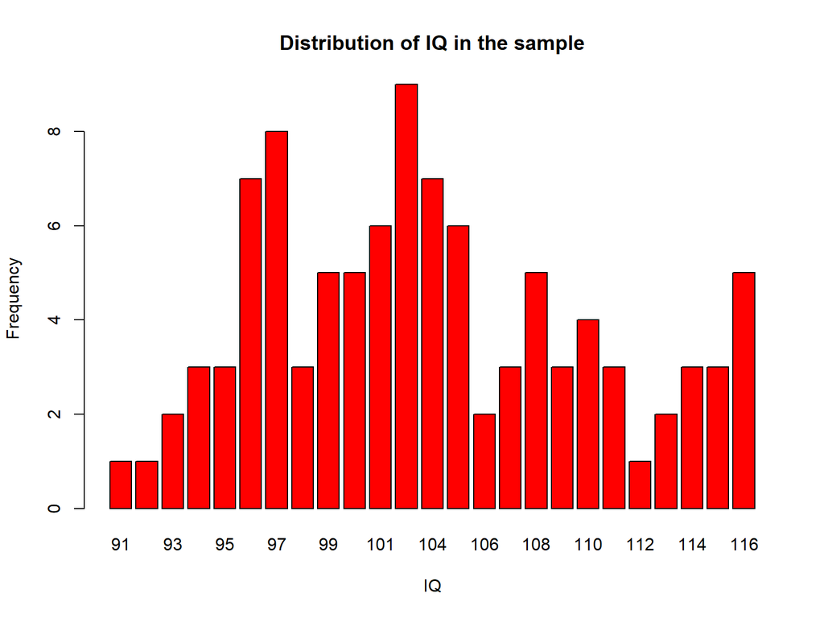

```r
barplot(table(df$IQ),
        xlab="IQ", # x-axis label
        ylab="Frequency", # y-axis label
        main="Distribution of IQ in the sample", # title at the top of the plot
        col="red") # bar color
```

## Let’s add descriptive statistics to the title

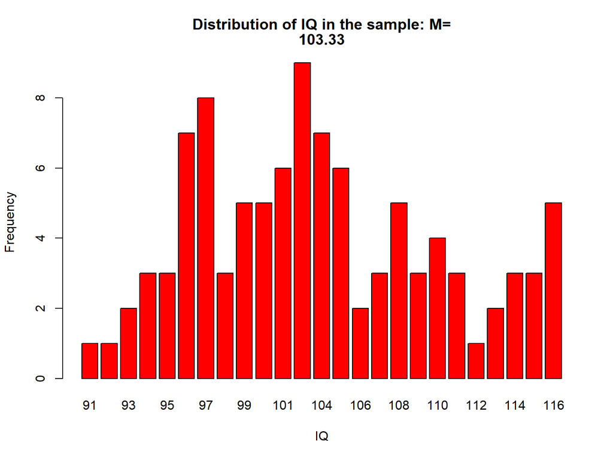

```r
barplot(table(df$IQ),
        xlab="IQ",
        ylab="Frequency",
        main=c("Distribution of IQ in the sample: M=",
               mean(df$IQ)), # combine text and values
        col="red")
```

## We can save the plot to a file

```r
png("Figure1.png",
    width=400, height=400)

plot(density(df$IQ))

dev.off()
```

## Graphical parameters

- A plot, as an object R operates on, has a number of characteristics
- We can control the plot’s appearance ourselves by setting values for graphical parameters
- We do this with the par() command, listing inside the parentheses what we want to set
- To find out which parameters exist and how to change them, type this command or check the Help:

```r
par() # also ?par
```

```
## $xlog
## [1] FALSE
##
## $ylog
## [1] FALSE
##
## $adj
## [1] 0.5
##
## $ann
## [1] TRUE
##
## $ask
## [1] FALSE
##
## $bg
## [1] "white"
##
## $bty
## [1] "o"
##
## $cex
## [1] 1
##
## $cex.axis
## [1] 1
##
## $cex.lab
## [1] 1
##
## $cex.main
## [1] 1.2
##
## $cex.sub
## [1] 1
##
## $cin
## [1] 0.15 0.20
##
## $col
```

[output cut: 160 more lines]

```
##
## $xpd
## [1] FALSE
##
## $yaxp
## [1] 0 1 5
##
## $yaxs
## [1] "r"
##
## $yaxt
## [1] "s"
##
## $ylbias
## [1] 0.2
```

> Fun fact

> The output of par() is a list

```r
class(par())
```

```
## [1] "list"
```

## You can also save your favorite settings into a variable, then call it later

- E.g.:

```r
# my_style <- par(bg="transparent", col = "red", cex = 0.7)
# par(my_style)
```

## Let’s display the IQ distribution separately for left-handed and right-handed participants

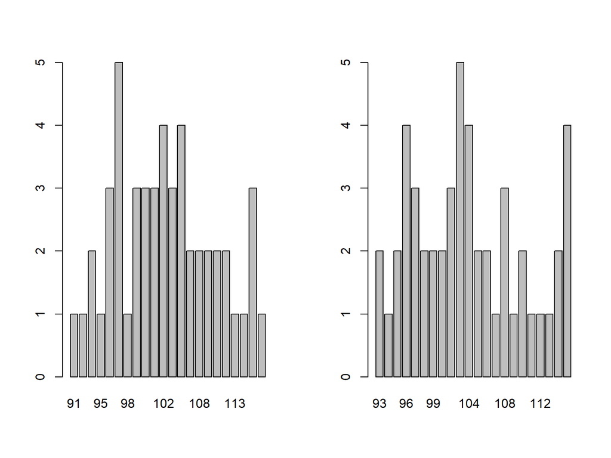

```r
par(mfrow=c(1, 2)) # set the graphical parameter to a grid of 1 row and 2 columns

barplot(table(df[df$DominantHand=="lefthanded",]$IQ)) # get IQ only for left-handed

barplot(table(df[df$DominantHand=="righthanded",]$IQ)) # get IQ only for right-handed
```

```r
par(mfrow=c(1,1)) # reset the graphical parameter to a grid of 1 row and 1 column
                  # to avoid future confusion
```

- The same plot with labels and title included

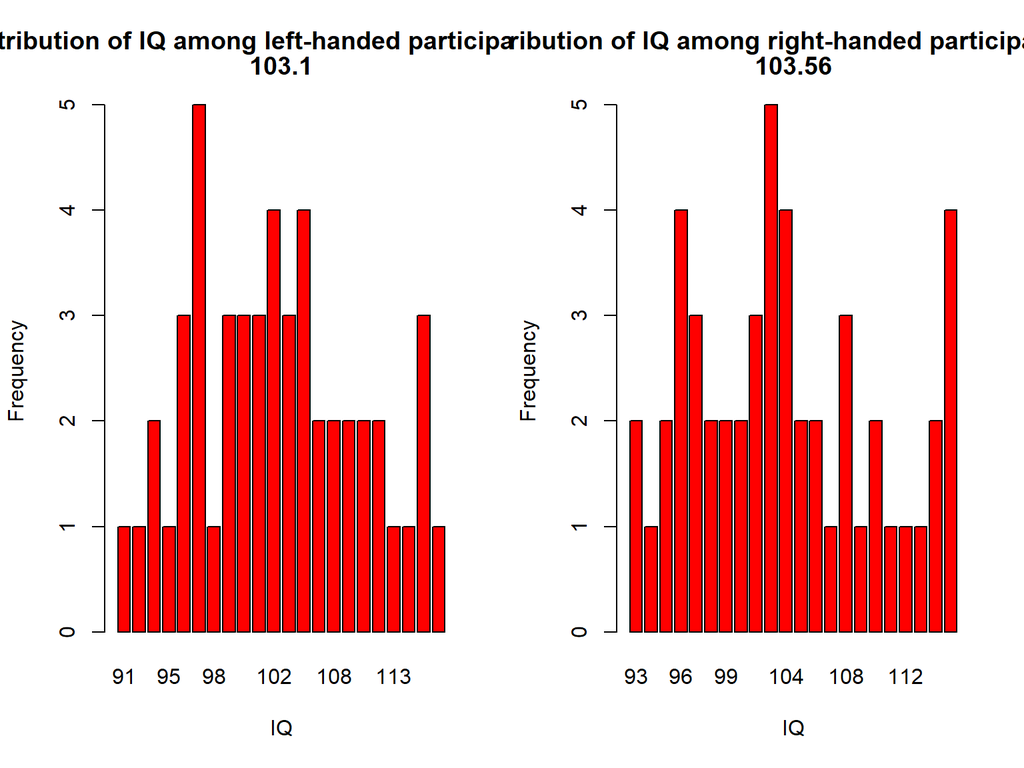

```r
par(mfrow=c(1, 2))

barplot(table(df[df$DominantHand=="lefthanded",]$IQ),
        xlab="IQ",
        ylab="Frequency",
        main=c("Distribution of IQ among left-handed participants: M=",
               mean(df[df$DominantHand=="lefthanded",]$IQ)),
        col="red")

barplot(table(df[df$DominantHand=="righthanded",]$IQ),
        xlab="IQ",
        ylab="Frequency",
        main=c("Distribution of IQ among right-handed participants: M=",
               mean(df[df$DominantHand=="righthanded",]$IQ)),
        col="red")
```

```r
par(mfrow=c(1,1))
```

## Let’s display the IQ distribution separately for left-handed and right-handed participants, and within each, separately for the control and experimental groups

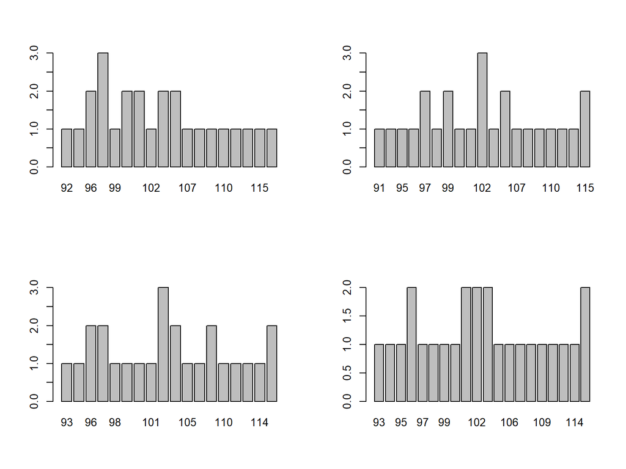

```r
par(mfrow=c(2, 2)) # create a grid of two rows and two columns (each cell for one plot)

barplot(table(df[df$DominantHand=="lefthanded" & df$Manipulation=="control_group",]$IQ))

barplot(table(df[df$DominantHand=="lefthanded" & df$Manipulation=="experimental_group",]$IQ))

barplot(table(df[df$DominantHand=="righthanded" & df$Manipulation=="control_group",]$IQ))

barplot(table(df[df$DominantHand=="righthanded" & df$Manipulation=="experimental_group",]$IQ))
```

```r
par(mfrow=c(1,1))
```

> Fun fact

> Plots are drawn by filling the first row left to right, then the second row. If you want them arranged by filling the first column top to bottom instead, type par(mfcol=c(2, 2))

## The same plot with labels included

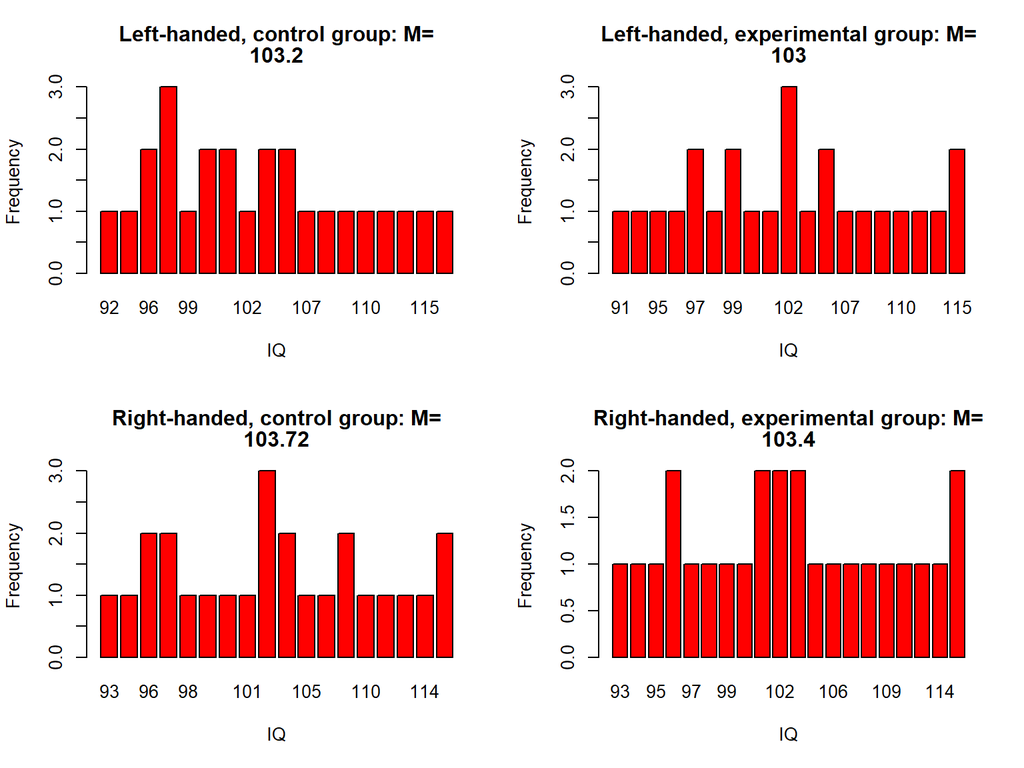

```r
par(mfrow=c(2, 2))
barplot(table(df[df$DominantHand=="lefthanded" & df$Manipulation=="control_group",]$IQ),
        xlab="IQ",
        ylab="Frequency",
        main=c("Left-handed, control group: M=",
               mean(df[df$DominantHand=="lefthanded" & df$Manipulation=="control_group",]$IQ)),
        col="red")

barplot(table(df[df$DominantHand=="lefthanded" & df$Manipulation=="experimental_group",]$IQ),
        xlab="IQ",
        ylab="Frequency",
        main=c("Left-handed, experimental group: M=", mean(df[df$DominantHand=="lefthanded" & df$Manipulation=="experimental_group",]$IQ)),
        col="red")

barplot(table(df[df$DominantHand=="righthanded" & df$Manipulation=="control_group",]$IQ),
        xlab="IQ",
        ylab="Frequency",
        main=c("Right-handed, control group: M=",
               mean(df[df$DominantHand=="righthanded" & df$Manipulation=="control_group",]$IQ)),
        col="red")

barplot(table(df[df$DominantHand=="righthanded" & df$Manipulation=="experimental_group",]$IQ),
        xlab="IQ",
        ylab="Frequency",
        main=c("Right-handed, experimental group: M=", mean(df[df$DominantHand=="righthanded" & df$Manipulation=="experimental_group",]$IQ)),
        col="red")
```

```r
par(mfrow=c(1,1))
```

## An alternative way, which gives a bit more freedom

```r
my_grid <- matrix(c(1, 2, 1, 3, 4, 4), nrow = 3, ncol = 2, byrow=TRUE)
# we create a matrix with as many cells
# i.e. rows and columns as the number of plots we want, and
# we arrange numbers in the matrix in the way we want the plots to be laid out,
# where the order of the plots corresponds to the order in which we supply them

my_grid # let's see what the layout matrix looks like
```

```
##      [,1] [,2]
## [1,]    1    2
## [2,]    1    3
## [3,]    4    4
```

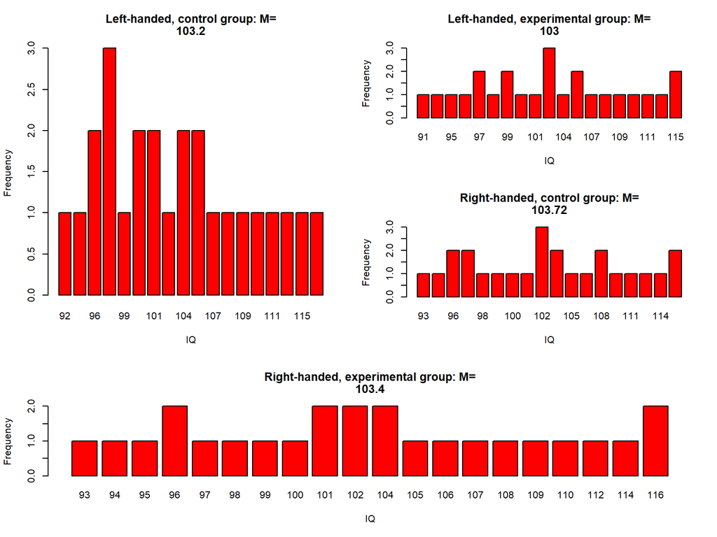

```r
layout(my_grid) # ask for the layout to follow our matrix

barplot(table(df[df$DominantHand=="lefthanded" & df$Manipulation=="control_group",]$IQ),
        xlab="IQ",
        ylab="Frequency",
        main=c("Left-handed, control group: M=",
               mean(df[df$DominantHand=="lefthanded" & df$Manipulation=="control_group",]$IQ)),
        col="red")

barplot(table(df[df$DominantHand=="lefthanded" & df$Manipulation=="experimental_group",]$IQ),
        xlab="IQ",
        ylab="Frequency",
        main=c("Left-handed, experimental group: M=",
               mean(df[df$DominantHand=="lefthanded" & df$Manipulation=="experimental_group",]$IQ)),
        col="red")

barplot(table(df[df$DominantHand=="righthanded" & df$Manipulation=="control_group",]$IQ),
        xlab="IQ",
        ylab="Frequency",
        main=c("Right-handed, control group: M=",
               mean(df[df$DominantHand=="righthanded" & df$Manipulation=="control_group",]$IQ)),
        col="red")

barplot(table(df[df$DominantHand=="righthanded" & df$Manipulation=="experimental_group",]$IQ),
        xlab="IQ",
        ylab="Frequency",
        main=c("Right-handed, experimental group: M=",
               mean(df[df$DominantHand=="righthanded" & df$Manipulation=="experimental_group",]$IQ)),
        col="red")
```

```r
layout(1) # reset the plot layout grid
```

## Let’s make a histogram for the IQ distribution

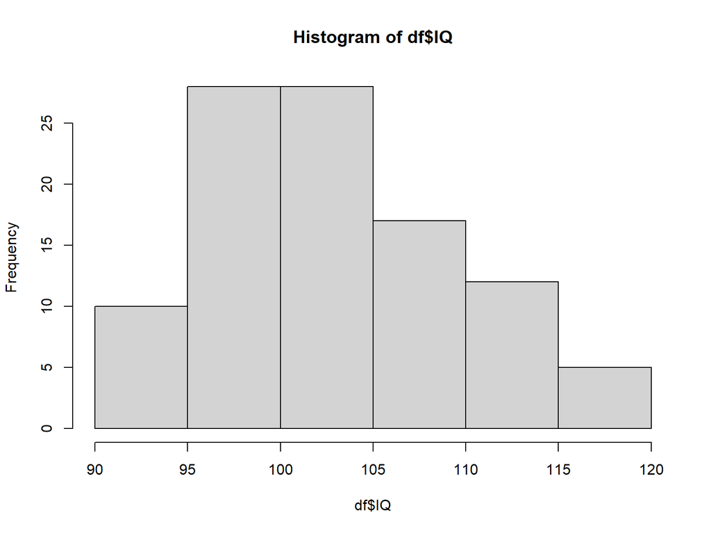

```r
hist(df$IQ)
```

## Same thing, but we set the number of categories ourselves

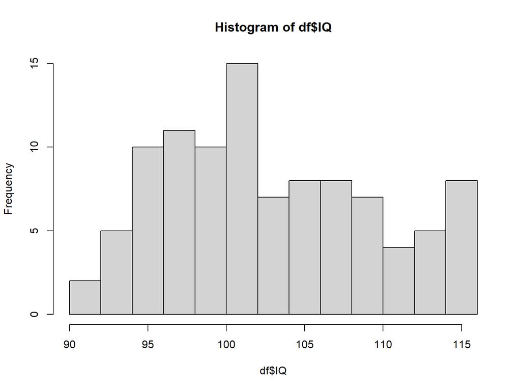

```r
hist(df$IQ, breaks=10)
```

## Let’s display the density of the IQ variable’s distribution

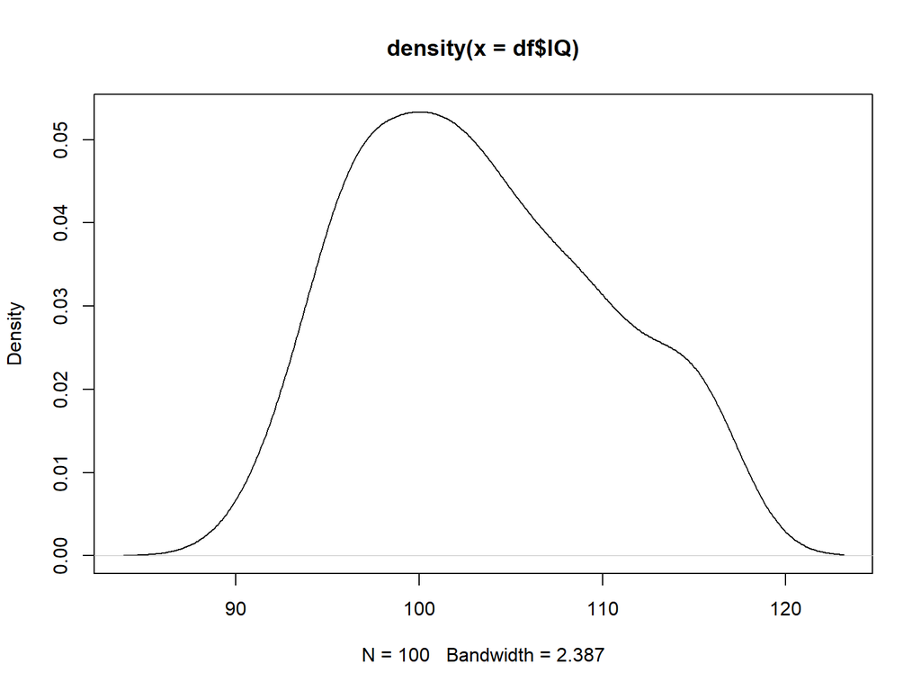

```r
plot(density(df$IQ))
```

## Cumulatively

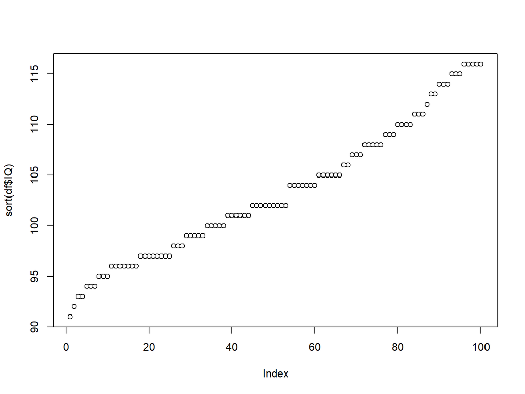

```r
plot(sort(df$IQ))
```

## Quantiles

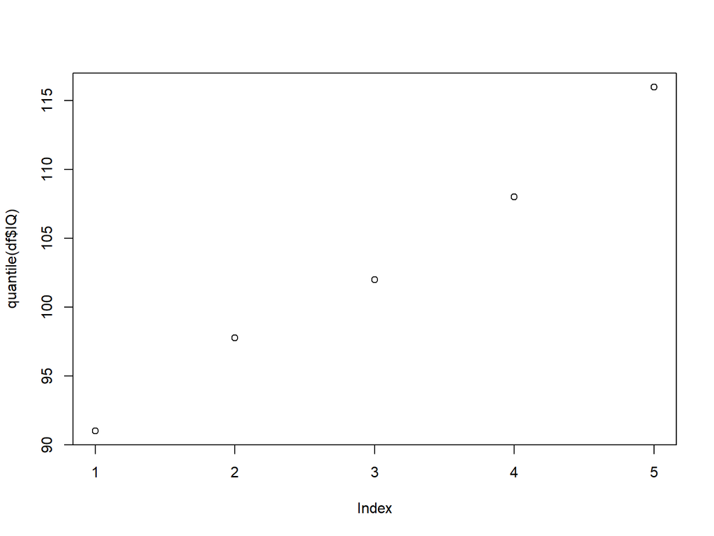

```r
plot(quantile(df$IQ))
```

## Deciles

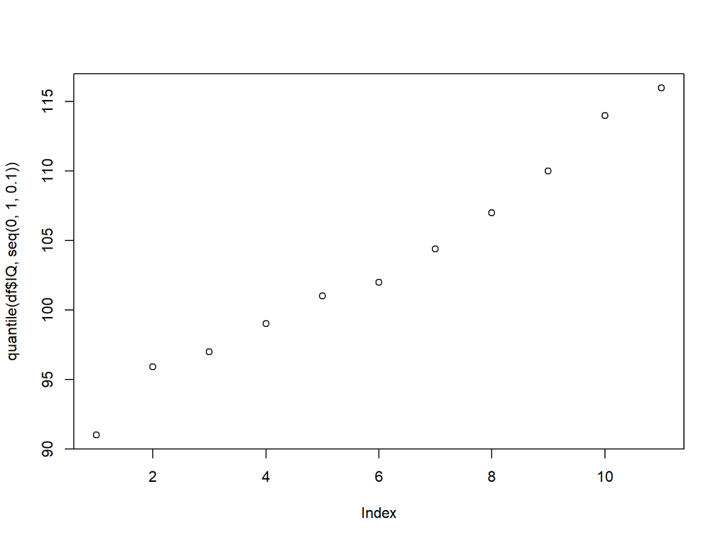

```r
plot(quantile(df$IQ, seq(0,1, 0.1)))
```

## qqplot

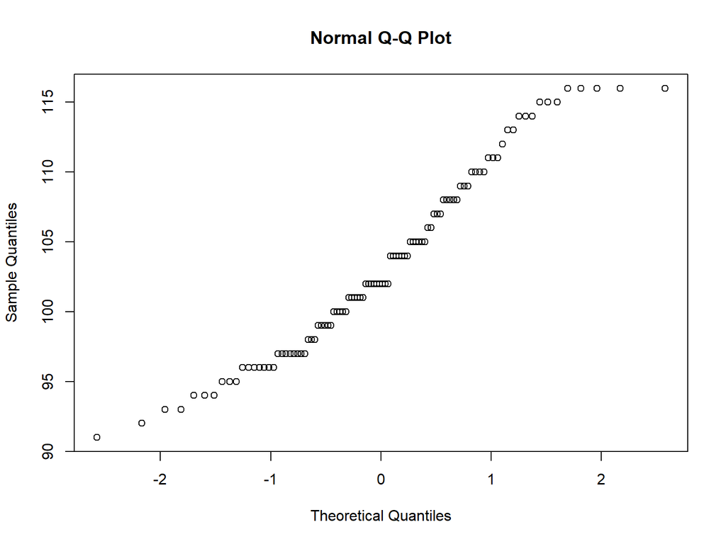

```r
qqnorm(df$IQ)
```

## Scatterplot

- The first argument: what is mapped to the x-axis, the second argument: what is mapped to the y-axis

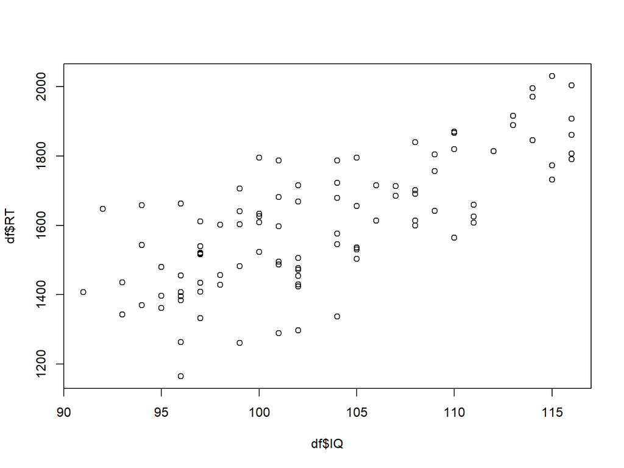

```r
plot(df$IQ, df$RT)
```

## Let’s add the correlation coefficient to the title

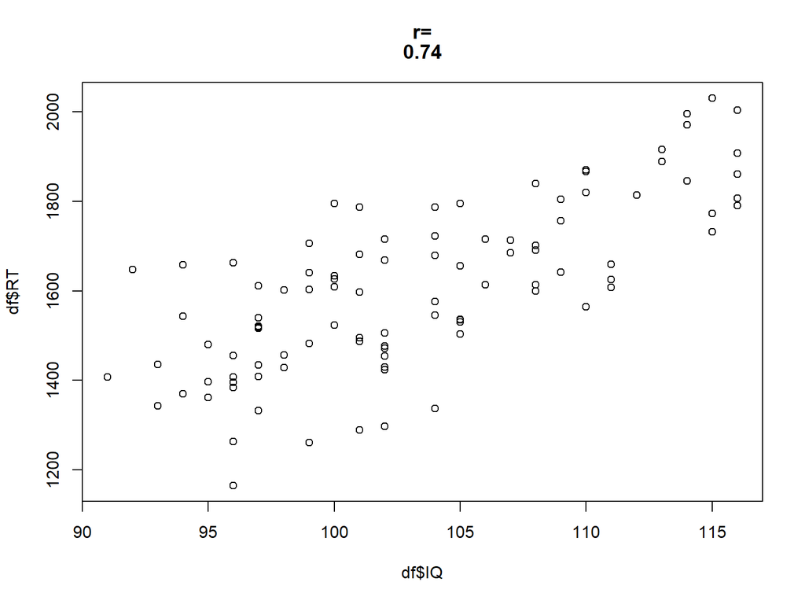

```r
x=cor(df$IQ, df$RT) # calculate the correlation coefficient between two variables
x= round(x,2) # round to two decimal places

plot(df$IQ, df$RT,
     main=c("r=", x)) # combine text and a number (the r value) in the title
```

## Instead of points, let’s display subject labels

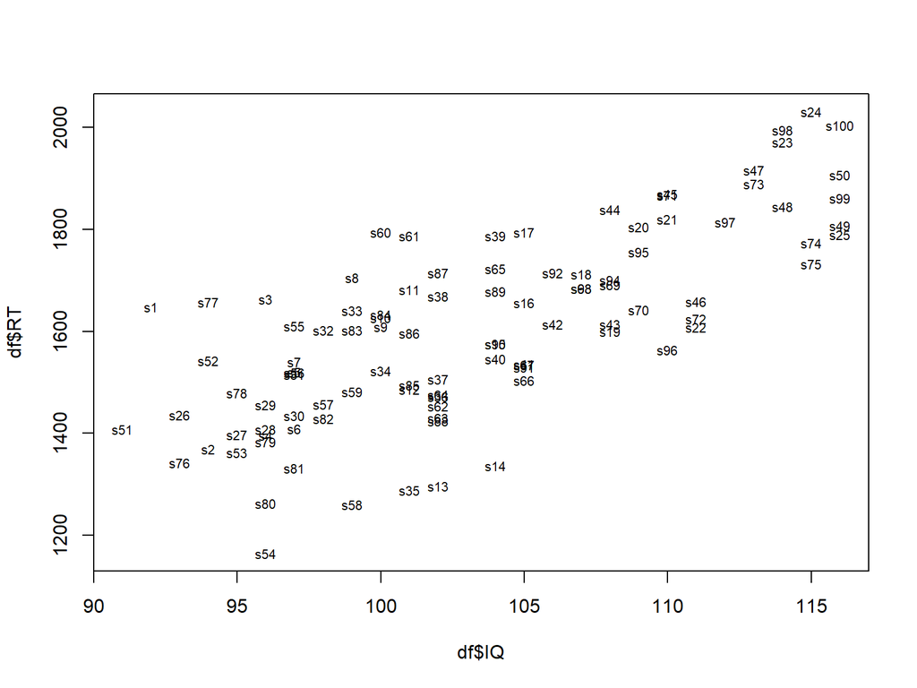

```r
plot(df$IQ, df$RT,
     type="n") # set the point type to "none" -- "don't add anything"

text(df$IQ, df$RT, # command for adding words instead of points to the plot;
                   # first we give the coordinates
     as.character(df$Participant), # then we say what should be displayed;
                                   # we convert to characters, because
                                   # this command requires a vector of strings
     cex=0.7) # shrink the font to make it more readable
```

## Let’s add a regression line

- Prepare the plot

```r
plot(df$IQ, df$RT,
     type="n") # set the point type to "none" -- "don't add anything"

text(df$IQ, df$RT, # command for adding words instead of points to the plot;
                   # first we give the coordinates
     as.character(df$Participant), # then we say what should be displayed;
                                   # we convert to characters, because
                                   # this command requires a vector of strings
     cex=0.7) # shrink the font to make it more readable


# Build a linear model (to calculate parameter for the regression line)

lm_df <- lm(RT ~ IQ, data=df) # first we build a linear model
# we get an object that contains the regression coefficients
coef(lm_df) # let's see the coefficients
```

```
## (Intercept)          IQ
##  -497.52579    20.35726
```

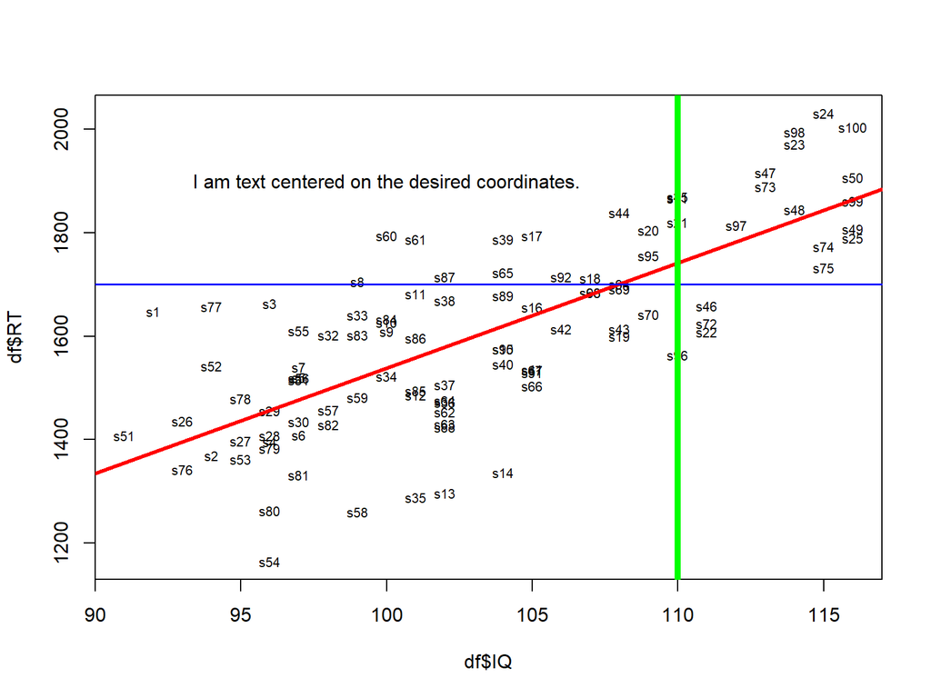

```r
abline(a=coef(lm_df)[1], b=coef(lm_df)[2])
# based on these coefficients, draw the regression line

abline(coef(lm_df)) # this is the same as the command in the line above, just shorter

# Play around

abline(coef(lm_df), lwd = 3) # thicken the line

abline(coef(lm_df), lwd = 3, col="red") # make the line red

abline(h=1700, lwd=1.5, col="blue") # add a horizontal line

abline(v=110, lwd=5, col="green") # add a vertical line

text(100, 1900, "I am text centered on the desired coordinates.")
```